# Dimensionality Reduction

←Back to the bookChapter 115 · Dimensionality Reduction

Chapter 115 · Dimensionality Reduction

Dimensionality Reduction

Compressing eight correlated nutrition columns into a few informative axes with PCA, reading the scree plot, loadings, and biplot, using the components to compress and denoise, and contrasting the linear PCA with the nonlinear t-SNE and UMAP, all library-first with scikit-learn, and heavily visual.

Statistics, Data Science and AI: A Visual Handbook · John Fisher · 2026

# Dimensionality Reduction: many columns into a few

Real datasets are wide: dozens of correlated columns that are hard to plot, slow to model, and noisy. **Dimensionality reduction** compresses them into a handful of informative axes while keeping most of the information. This notebook uses **PCA** (principal component analysis) on packaged-food nutrition, reads its scree plot, loadings, and biplot, uses it to compress and denoise, and contrasts it with the nonlinear **t-SNE**. Library-first with `scikit-learn`.

```python
import numpy as np, pandas as pd, matplotlib.pyplot as plt
import seaborn as sns   # seaborn = high-level statistical plots (heatmaps, pairplots, count/bar plots)
from matplotlib.colors import ListedColormap
EM="#4338ca"; DEEP="#3730a3"; LIGHT="#c7d2fe"; INK="#1a2138"; GRID="#e6e9f2"; RED="#ef4444"; AMBER="#d97706"; GREEN="#059669"; BLUE="#2563eb"; PUR="#9333ea"; GREY="#94a3b8"; SLATE="#475569"; ORG="#4338ca"; CYAN="#0891b2"
plt.rcParams.update({"figure.facecolor":"white","axes.facecolor":"white","figure.dpi":110,"font.size":11,
   "axes.edgecolor":GRID,"axes.grid":True,"grid.color":GRID,"axes.axisbelow":True,"axes.spines.top":False,
   "axes.spines.right":False,"axes.titlesize":12,"axes.titleweight":"bold","legend.frameon":False})
sns.set_style("whitegrid")
BASE="https://raw.githubusercontent.com/johnfisher-ai/Statistics-Data-Science-AI-Visual-Book/main/data/"
```

```python
from sklearn.preprocessing import StandardScaler
from sklearn.decomposition import PCA
from sklearn.manifold import TSNE
pd.set_option('display.max_columns', 30)
```

DEMO 1 · TOO MANY COLUMNS

Eight correlated nutrition features

Load foods and see how tangled the columns are.

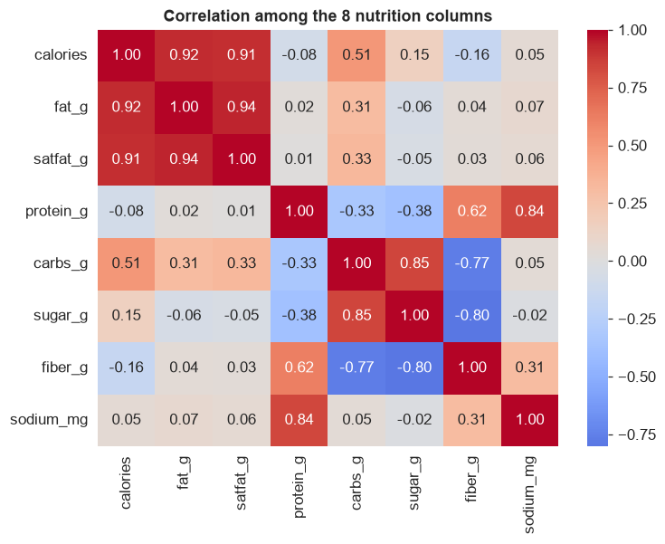

```python
try: df = pd.read_excel('../../data/ch115_foods.xlsx', sheet_name='Data')
except FileNotFoundError: df = pd.read_excel(BASE + 'ch115_foods.xlsx', sheet_name='Data')
num = ['calories','fat_g','satfat_g','protein_g','carbs_g','sugar_g','fiber_g','sodium_mg']
Xs = StandardScaler().fit_transform(df[num])   # PCA needs standardized inputs
fig, ax = plt.subplots(figsize=(7,5.6))
sns.heatmap(df[num].corr(), annot=True, fmt='.2f', cmap='coolwarm', center=0, ax=ax)
ax.set_title('Correlation among the 8 nutrition columns'); plt.tight_layout(); plt.show()
```

**Why reduce?** These eight columns are heavily correlated, calories move with fat and carbs, sugar moves against fiber, and so on. That redundancy means the data does not really live in 8 dimensions; a few underlying factors (energy density, sweet vs savory) drive everything. Dimensionality reduction finds those factors. As always with distance- and variance-based methods, we **standardize** first so a large-range column like sodium does not dominate purely because of its units.

DEMO 2 · PCA AND THE SCREE PLOT

How many dimensions do we really need?

PCA ranks new axes by how much variance each explains.

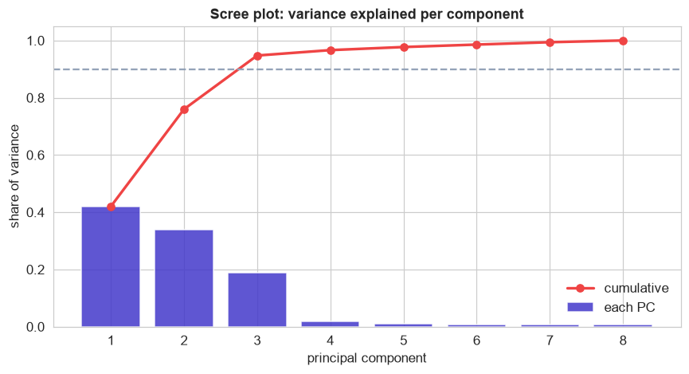

```
variance explained: PC1 42%  PC2 34%  PC3 19%
first 2 PCs: 76% of all variance | first 3: 95%
```

```python
pca = PCA().fit(Xs)
ev = pca.explained_variance_ratio_
cum = np.cumsum(ev)
fig, ax = plt.subplots(figsize=(8,4.4))
ax.bar(range(1,9), ev, color=EM, alpha=0.85, label='each PC')
ax.plot(range(1,9), cum, 'o-', color=RED, lw=2.2, label='cumulative')
ax.axhline(0.9, color=GREY, ls='--'); ax.set(xlabel='principal component', ylabel='share of variance', title='Scree plot: variance explained per component'); ax.legend()
plt.tight_layout(); plt.show()
print('variance explained: PC1 %.0f%%  PC2 %.0f%%  PC3 %.0f%%' % (ev[0]*100, ev[1]*100, ev[2]*100))
print('first 2 PCs: %.0f%% of all variance | first 3: %.0f%%' % (cum[1]*100, cum[2]*100))
```

**Reading the scree plot.** PCA rebuilds the data on new perpendicular axes (principal components) ordered so the first captures the most variance, the second the next most, and so on. Here **PC1 explains 42%** and **PC2 34%**, so a 2D picture keeps **76%** of everything; adding PC3 reaches **95%**. The 8-column dataset was really only about 3 dimensions of information. The 'elbow' in the scree plot, and the point where the cumulative curve crosses 90%, tell you how many components to keep.

DEMO 3 · THE 2D MAP

Eight dimensions on one page

Project every food onto PC1 and PC2 and plot it.

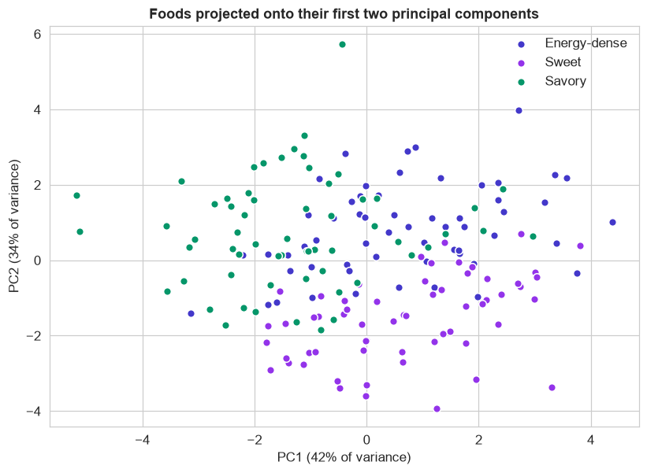

```python
P = PCA(n_components=2).fit_transform(Xs)
fig, ax = plt.subplots(figsize=(7.6,5.6))
for t,c in zip(['Energy-dense','Sweet','Savory'], [EM, PUR, GREEN]):
    m = df['food_type']==t
    ax.scatter(P[m,0], P[m,1], s=40, c=c, edgecolor='white', label=t)
ax.set(xlabel='PC1 (42% of variance)', ylabel='PC2 (34% of variance)', title='Foods projected onto their first two principal components'); ax.legend()
plt.tight_layout(); plt.show()
```

**A readable map.** Each food is now a single dot in a 2D plane, its coordinates are its scores on PC1 and PC2. Even though PCA never saw the `food_type` label (it is **unsupervised**), coloring the dots by type shows the categories fall in distinct regions: the compression preserved the real structure. This is the everyday magic of PCA, turning an un-plottable 8-column table into one honest picture you can actually look at.

DEMO 4 · LOADINGS AND THE BIPLOT

What do the new axes mean?

Loadings show which original columns build each PC.

```
            PC1   PC2
calories   0.43  0.35
fat_g      0.35  0.44
satfat_g   0.35  0.43
protein_g -0.27  0.37
carbs_g    0.47 -0.13
sugar_g    0.35 -0.33
fiber_g   -0.38  0.39
sodium_mg -0.11  0.29
```

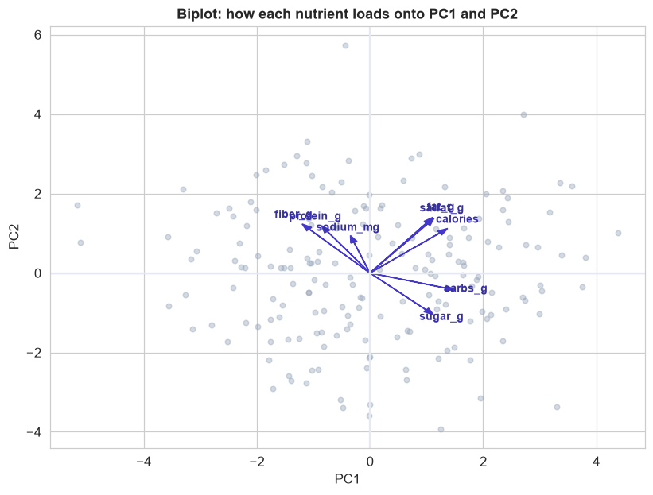

```python
pca2 = PCA(n_components=2).fit(Xs)
comp = pca2.components_
load = pd.DataFrame(comp.T, index=num, columns=['PC1','PC2']).round(2)
print(load.to_string())
fig, ax = plt.subplots(figsize=(7.6,5.8))
ax.scatter(P[:,0], P[:,1], s=18, c=GREY, alpha=0.4)
for i,name in enumerate(num):
    ax.arrow(0,0, comp[0,i]*3.2, comp[1,i]*3.2, color=EM, width=0.006, head_width=0.12, length_includes_head=True)
    ax.text(comp[0,i]*3.6, comp[1,i]*3.6, name, color=DEEP, fontsize=9, ha='center', fontweight='bold')
ax.axhline(0,color=GRID); ax.axvline(0,color=GRID); ax.set(xlabel='PC1', ylabel='PC2', title='Biplot: how each nutrient loads onto PC1 and PC2')
plt.tight_layout(); plt.show()
```

**Interpreting the axes.** Loadings are the recipe for each component. **PC1** loads high on calories, carbs, and sugar and low on fiber and protein, it is a 'carb-and-calorie load' axis. **PC2** loads high on fat, saturated fat, and protein, it is a 'richness/fat' axis. In the **biplot**, each arrow is a nutrient: arrows pointing the same way are correlated, opposite arrows are anti-correlated (sugar vs fiber), and a food sitting far along an arrow is high in that nutrient. This is what makes PCA **interpretable**, the axes are readable combinations of the originals, not a black box.

DEMO 5 · COMPRESSION AND DENOISING

Keep a few PCs, throw the rest away

Reconstruct the data from only the top components.

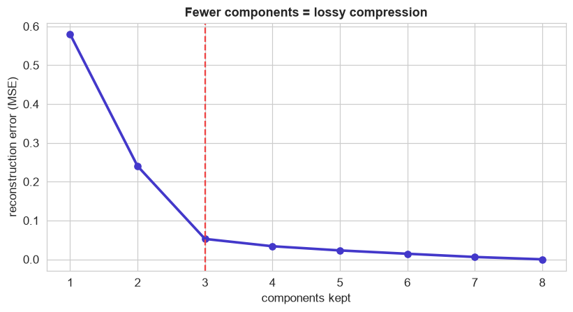

```
keeping 3 of 8 components reconstructs the data with error 0.053 and retains 95% of variance
```

```python
errs = []
for k in range(1,9):
    pk = PCA(n_components=k).fit(Xs)
    recon = pk.inverse_transform(pk.transform(Xs))
    errs.append(np.mean((Xs - recon)**2))
fig, ax = plt.subplots(figsize=(7.6,4.2))
ax.plot(range(1,9), errs, 'o-', color=EM, lw=2.4)
ax.set(xlabel='components kept', ylabel='reconstruction error (MSE)', title='Fewer components = lossy compression')
ax.axvline(3, color=RED, ls='--'); plt.tight_layout(); plt.show()
print('keeping 3 of 8 components reconstructs the data with error %.3f and retains 95%% of variance' % errs[2])
```

**A dial between size and fidelity.** Reconstructing each food from only its top-`k` component scores is **lossy compression**: fewer components mean a smaller representation but a larger reconstruction error. The curve drops steeply then flattens, keeping just 3 of the 8 components rebuilds the table almost perfectly (95% of the variance). Because the discarded components are mostly noise, this step also **denoises** the data, which is exactly why PCA is a standard preprocessing step before clustering or supervised models on wide, correlated data.

DEMO 6 · NONLINEAR: t-SNE

When straight axes are not enough

t-SNE unfolds curved structure for visualization.

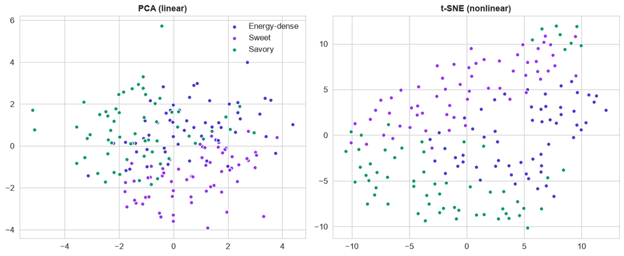

```python
emb = TSNE(n_components=2, perplexity=30, random_state=0, init='pca').fit_transform(Xs)
fig, ax = plt.subplots(1, 2, figsize=(12,5))
for t,c in zip(['Energy-dense','Sweet','Savory'], [EM, PUR, GREEN]):
    m = df['food_type']==t
    ax[0].scatter(P[m,0], P[m,1], s=28, c=c, edgecolor='white', label=t)
    ax[1].scatter(emb[m,0], emb[m,1], s=28, c=c, edgecolor='white', label=t)
ax[0].set_title('PCA (linear)'); ax[1].set_title('t-SNE (nonlinear)'); ax[0].legend()
plt.tight_layout(); plt.show()
```

**Linear vs nonlinear.** PCA can only rotate and stretch, it finds straight axes, which makes it fast, reversible, and interpretable. **t-SNE** (and its faster cousin **UMAP**) instead preserve *local neighborhoods*, unfolding curved manifolds into tidy islands that often separate groups more crisply. The trade-offs: t-SNE and UMAP are for **visualization only** (the axes have no units, distances between clusters are not meaningful, and you cannot project new points reversibly). Rule of thumb: reach for **PCA** to compress, denoise, and interpret; reach for **t-SNE/UMAP** to make a striking 2D picture of high-dimensional data.

## Dimensionality reduction, in one view

- **Wide, correlated data** does not need all its columns, a few latent factors drive it.
- **PCA** builds ranked perpendicular axes; the **scree plot** and the 90% cumulative line tell you how many to keep.
- **Loadings / biplot** make the components interpretable (which original columns build each axis).
- Keeping the top few components **compresses and denoises**, a standard preprocessing step.
- **PCA** is linear and interpretable; **t-SNE / UMAP** are nonlinear and for visualization only.

Statistics, Data Science and AI: A Visual Handbook · © 2026 John Fisher

←Back to the bookChapter 115 · Dimensionality Reduction